# EVDS Data Analysis - Homework 1

## Installation of R packages

```r
library(tidyverse)
library(lubridate)
library(zoo)
library(readxl)
library(dplyr)
library(ggplot2)
```

## Choosing data from EVDS

For the analysis, the data is chosen as monthly and for three years period.Car purchases (araç satın alımı) from customer price index category “TP.FG.J071” is chosen and named as “Car_Purchasing_Index”. Car rental, sales,spare parts data (araç kiralama/satış/yedek parça), which is coded in EVDS as “TP.KKHARTUT.KT3”, from bank and credit cards spendings (banka kartı ve kredi kartı harcama tutarı(bin tl)) category is chosen and names as “Car_Rental_and_Sales”. Lastly, the manufactured vehicle (binek araç üretimi) data “TP.UR.S08” is chosen from the production category and named as “Manufactured_Automobile_Number”. The relation between car purchases, credit card spendings for car expenses and total produced car is investigated.

```r
library(readxl)
car <- read_excel("C:/Users/Gaye/Desktop/ETM58D - Business Analytics/car.xlsx")
View(car)

colnames(car) <- c("Date", "Car_Rental_and_Sales", "Car_Purchasing_Index", "Manufactured_Automobile_Number")
str(car)
```

```
## tibble[,4] [36 x 4] (S3: tbl_df/tbl/data.frame)
##  $ Date                          : chr [1:36] "2018-04" "2018-05" "2018-06" "2018-07" ...
##  $ Car_Rental_and_Sales          : num [1:36] 2133772 2069844 2714644 2172956 2498474 ...
##  $ Car_Purchasing_Index          : num [1:36] 290 296 308 312 330 ...
##  $ Manufactured_Automobile_Number: num [1:36] 90789 95677 85635 96511 29289 ...
```

## Plotting data

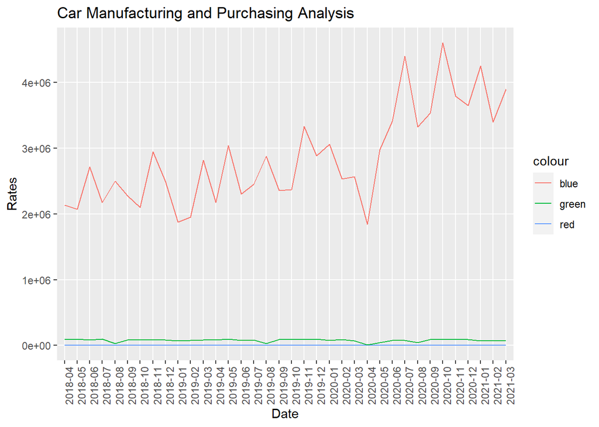

```r
library(ggplot2)
plotting <- ggplot(car, aes(x=Date, group=1))+
    geom_line(aes(y=Car_Rental_and_Sales,color="blue"))+
  geom_line(aes(y=Car_Purchasing_Index, color="red"))+
  geom_line(aes(y=Manufactured_Automobile_Number, color="green"))+
  theme(panel.grid.minor = element_blank(),
    axis.text.x = element_text(angle=90))+
   labs(x = "Date", y = "Rates",
              title = "Car Manufacturing and Purchasing Analysis")
plotting
```

## Analysis

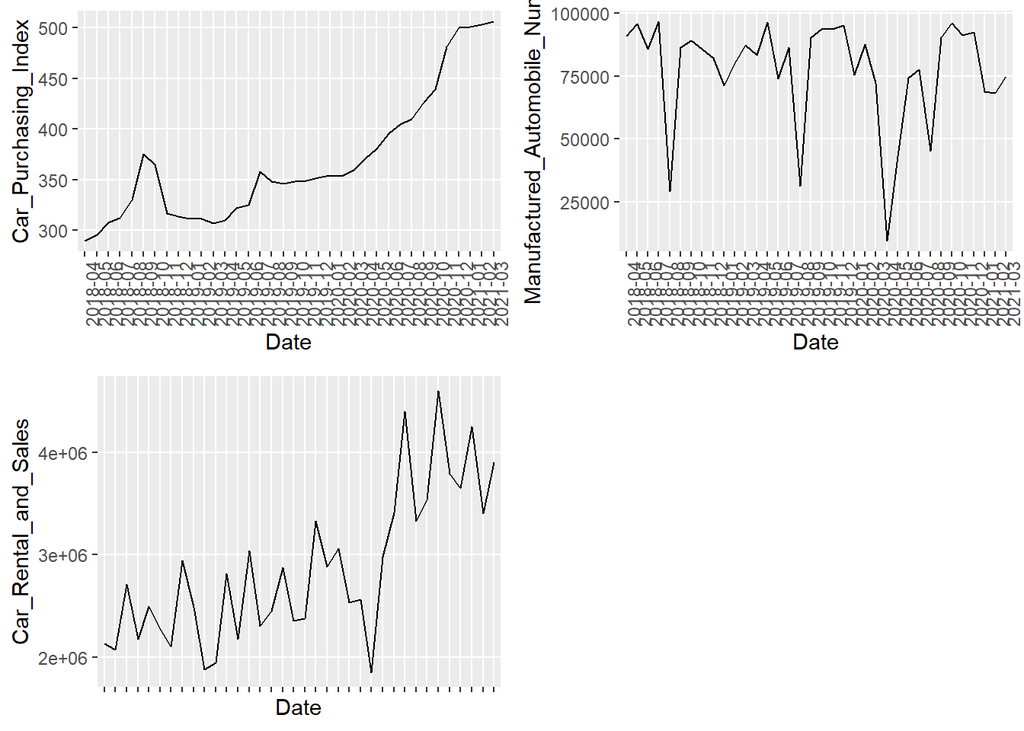

```r
plot1 <- ggplot(car, aes(x=Date, group=1))+
  geom_line(aes(y=Car_Purchasing_Index))+
    theme(panel.grid.minor = element_blank(),
    axis.text.x = element_text(angle=90))

plot2 <- ggplot(car, aes(x=Date, group=1))+
  geom_line(aes(y=Manufactured_Automobile_Number))+
    theme(panel.grid.minor = element_blank(),
    axis.text.x = element_text(angle=90))

plot3 <- ggplot(car, aes(x=Date, group=1))+
  geom_line(aes(y=Car_Rental_and_Sales))+
    theme(panel.grid.minor = element_blank(),
    axis.text.x = element_text(angle=90))


library(ggpubr)

ggarrange(plot1, plot2, plot3 + rremove("x.text"),
          ncol = 2, nrow = 2)
```

## Detailed analysis of data

As it can be seen from the above graphs, there is no parallel trend between Car_Rental_and_Sales(blue) data and Manufactured_Automobile_Number(green) data. However, from the 4th month of 2020, vehicle production is increasing and credit card spendings on car expenses (Car_Rental_and_Sales) data is also increasing similarly. One reason for this increase may be the pandemic because people tend to live individually after the pandemic risk. Therefore, the tendency to buy vehicles may result in an increase of vehicle production. When comparing the car purchases and the credit card spendings on car expenses data both of them have an increasing trend, especially from the 4th month of 2020. So it can be inferred that there is a relation between three data and this may be due to covid-19 pandemic.

## Google trends analysis key word choices

Each data category is compared with the key word searched in Google trends. The key words chosen for each data set is as follows: “araba kredi” key word is chosen for bank an credit card spendigns for car rental, sales, spare parts expenses, “araba fiyatları” key word is chosen for car purchases, “araba” key word is chosen for the manufactured vehicle data.

## Reading and arranging data

The data downloaded from Google trends page is weekly, but the EVDS data is monthly so Google trends data is re-arranged as monthly and the mean of the search key word is gathered. car loan (araba kredi) data, car price (araba fiyatları) data and car (araba) data is arranged below, respectively.

```r
library(readxl)
car_loan <-read_xlsx("C:/Users/Gaye/Desktop/ETM58D - Business Analytics/car_loan.xlsx")
View(car_loan)

library(dplyr)
library(zoo)
library(tidyverse)
car_loan <- arrange (car_loan, Date)
car_loan$Date <- as.yearmon(car_loan$Date)
car_loan_mnth <- car_loan %>%
  group_by(Date) %>%
  summarise_all(mean)

write_csv(car_loan_mnth, file ="MonthlyCarLoan.csv")


car_price<-read_excel("C:/Users/Gaye/Desktop/ETM58D - Business Analytics/car_price.xlsx")

car_price <- arrange (car_price, Date)
car_price$Date <- as.yearmon(car_price$Date)
car_price_mnth <- car_price %>%
  group_by(Date) %>%
  summarise_all(mean)

write_csv(car_price_mnth, file ="MonthlyCarPrice.csv")


car_vehicle<-read_excel("C:/Users/Gaye/Desktop/ETM58D - Business Analytics/car_vehicle.xlsx")

car_vehicle <- arrange (car_vehicle, Date)
car_vehicle$Date <- as.yearmon(car_vehicle$Date)
car_vehicle_mnth <- car_vehicle %>%
  group_by(Date) %>%
  summarise_all(mean)

write_csv(car_vehicle, file ="MonthlyCarVehicle.csv")
```

## Reading and plotting the merged trends data

## Graph analysis of “araba kredi” key word

```r
library(readxl)
Car_Google_Trends <- read_excel("C:/Users/Gaye/Desktop/ETM58D - Business Analytics/Car_Google_Trends.xlsx")
View(Car_Google_Trends)
str(Car_Google_Trends)
```

```
## tibble[,4] [32 x 4] (S3: tbl_df/tbl/data.frame)
##  $ Date     : chr [1:32] "2018-10" "2018-11" "2018-12" "2019-01" ...
##  $ Car_Loans: chr [1:32] "18.75" "19.75" "18.60" "23.50" ...
##  $ Car_Price: chr [1:32] "44.25" "46.0" "41.80" "39.25" ...
##  $ Car      : num [1:32] 60 61.5 59.2 62 61.2 ...
```

```r
df1 <- car %>%
  select(Date, Car_Rental_and_Sales)
df2<- Car_Google_Trends %>%
  select(Date, Car_Loans)
df3 <- left_join(df2, df1, by = "Date")
df3
```

```
## # A tibble: 32 x 3
##    Date    Car_Loans Car_Rental_and_Sales
##    <chr>   <chr>                    <dbl>
##  1 2018-10 18.75                  2097102
##  2 2018-11 19.75                  2943438
##  3 2018-12 18.60                  2490940
##  4 2019-01 23.50                  1876455
##  5 2019-02 21.50                  1948016
##  6 2019-03 20.0                   2817951
##  7 2019-04 19.50                  2172818
##  8 2019-05 19.50                  3041931
##  9 2019-06 19.80                  2303626
## 10 2019-07 24.0                   2449107
## # ... with 22 more rows
```

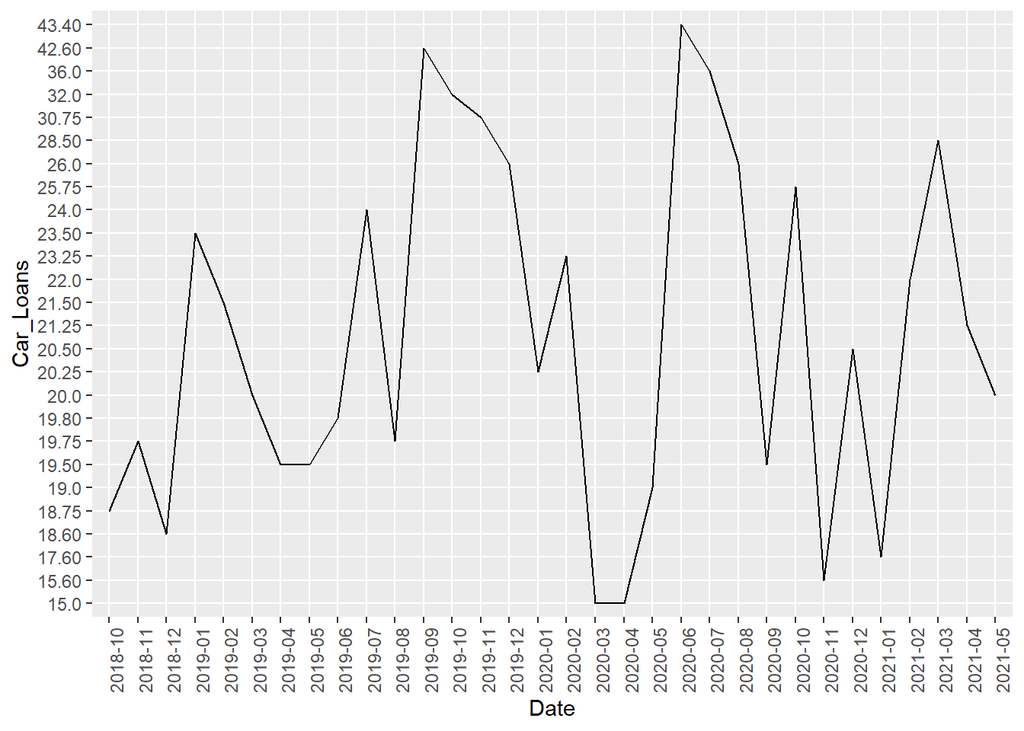

```r
plot_trend1 <- ggplot(df3, aes(x=Date, group=1))+
  geom_line(aes(y=Car_Loans))+
    theme(panel.grid.minor = element_blank(),
    axis.text.x = element_text(angle=90))
plot_trend1
```

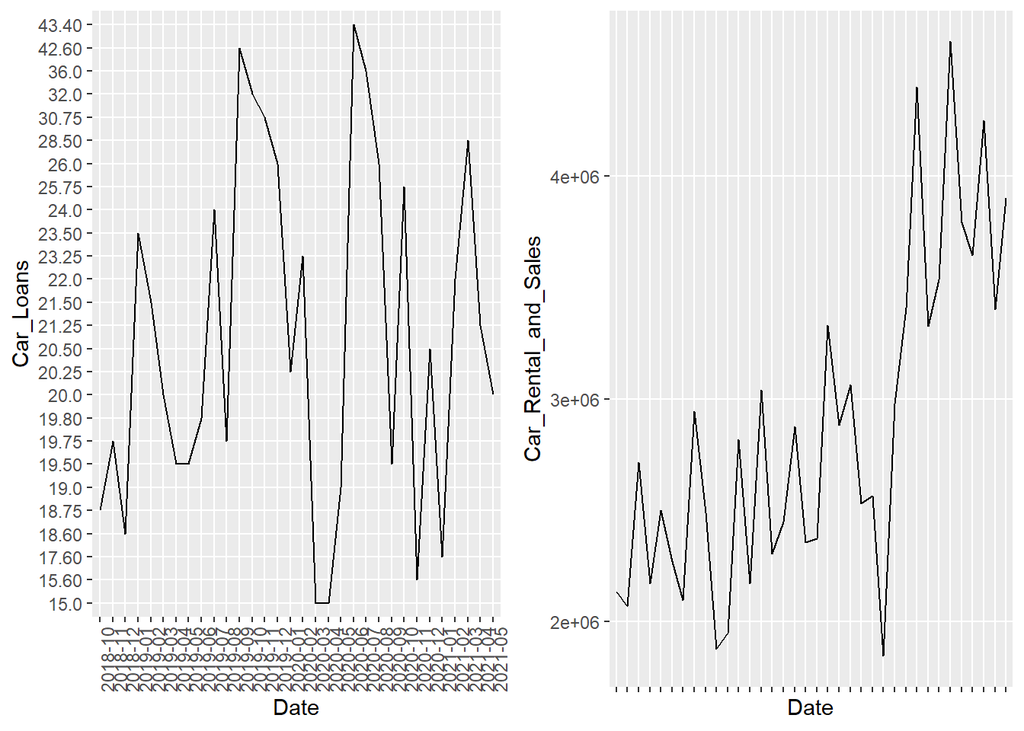

```r
ggarrange(plot_trend1, plot3 + rremove("x.text"),
          ncol = 2, nrow = 1)
```

“araba kredi” key word is chosen for the bank and credit card spendings of car rental, sales, spare parts expenses. The search rate for “araba kredi” is increasing from 2018 to 2020 and there is a sharp decrease at 2020. Also, Car_Rental_and_Sales graph shows the same sharp decrease. Both data is fluctuating and after 2020 there is an increase in Car_Rental_and_Sales data, however, in the Car_Loans graph the fluctuation also exists but no increase in the trend. We, can say that “araba kredi” search rate goes parallel with bank and credit card spendings of car expenses until 2020 but some changes occurred after that date.

## Graph analysis of “araba fiyatları” key word

```r
df_purchase <- car %>%
  select(Date, Car_Purchasing_Index)
df_price<- Car_Google_Trends %>%
  select(Date, Car_Price)
df4 <- left_join(df_price, df_purchase, by = "Date")
df4
```

```
## # A tibble: 32 x 3
##    Date    Car_Price Car_Purchasing_Index
##    <chr>   <chr>                    <dbl>
##  1 2018-10 44.25                     365.
##  2 2018-11 46.0                      317.
##  3 2018-12 41.80                     314.
##  4 2019-01 39.25                     312.
##  5 2019-02 38.25                     311.
##  6 2019-03 37.60                     307.
##  7 2019-04 35.25                     310.
##  8 2019-05 36.75                     322.
##  9 2019-06 47.6                      325.
## 10 2019-07 50.5                      358.
## # ... with 22 more rows
```

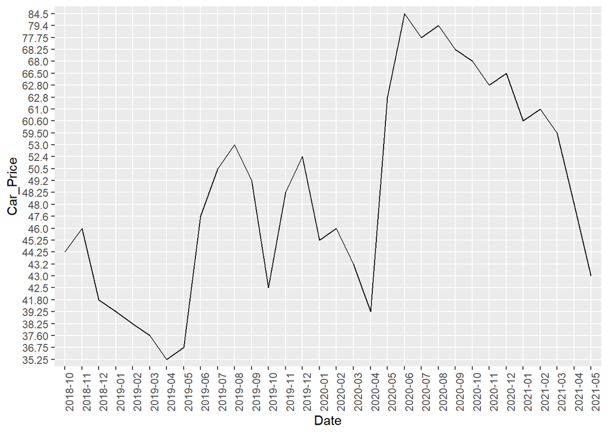

```r
plot_trend2 <- ggplot(df4, aes(x=Date, group=1))+
  geom_line(aes(y=Car_Price))+
    theme(panel.grid.minor = element_blank(),
    axis.text.x = element_text(angle=90))
plot_trend2
```

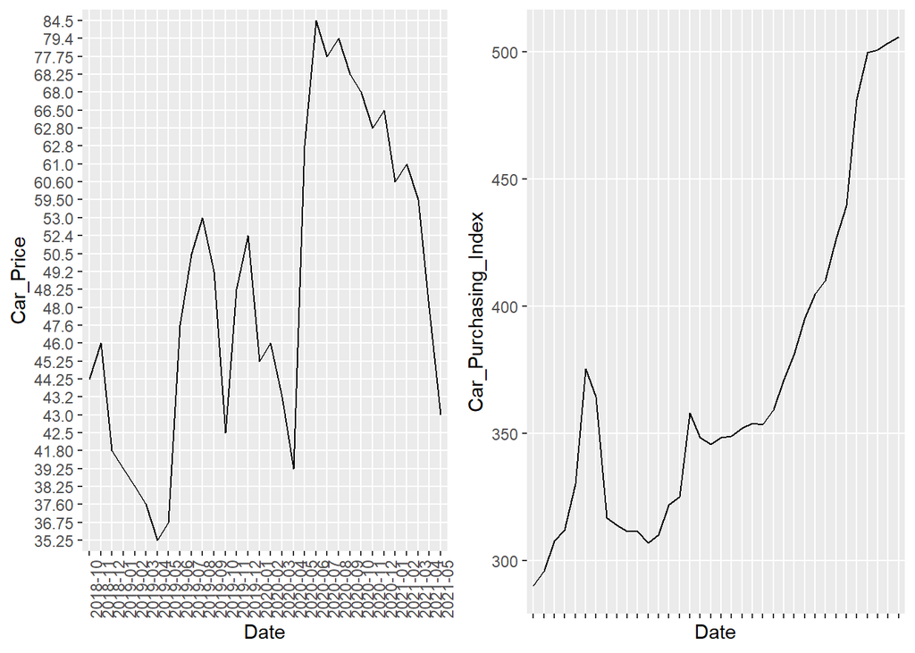

```r
ggarrange(plot_trend2, plot1 + rremove("x.text"),
          ncol = 2, nrow = 1)
```

“araba fiyatları” key word is chosen for the car purchase data. It can be expected that when car purchase data from consumer price index increase, “araba fiyatları” key word search rate should decrease. From the graphs above, it is seen that there is an opposite relation as expected. For instance, in the Car_Price graph search rate started to decrease from the middle of 2020 and in the Car_Purchasing_Index graph, car costs increase so there is an opposite relation.

## Graph analysis of “araba” key word

```r
df_production <- car %>%
  select(Date, Manufactured_Automobile_Number)
df_car<- Car_Google_Trends %>%
  select(Date, Car)
df5 <- left_join(df_production, df_car, by = "Date")
df5
```

```
## # A tibble: 36 x 3
##    Date    Manufactured_Automobile_Number   Car
##    <chr>                            <dbl> <dbl>
##  1 2018-04                          90789  NA
##  2 2018-05                          95677  NA
##  3 2018-06                          85635  NA
##  4 2018-07                          96511  NA
##  5 2018-08                          29289  NA
##  6 2018-09                          86395  NA
##  7 2018-10                          89151  60
##  8 2018-11                          85666  61.5
##  9 2018-12                          82157  59.2
## 10 2019-01                          71397  62
## # ... with 26 more rows
```

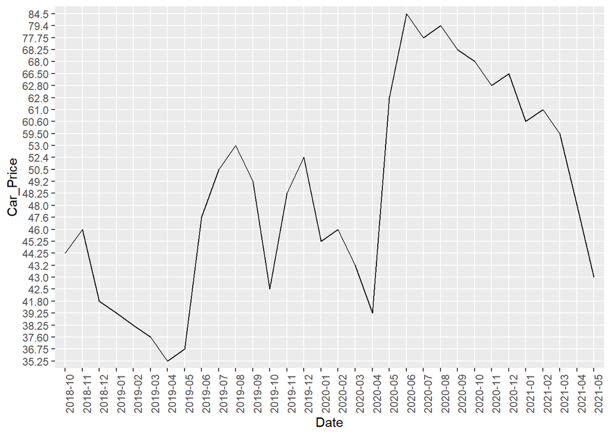

```r
plot_trend3 <- ggplot(df5, aes(x=Date, group=1))+
  geom_line(aes(y=Car))+
    theme(panel.grid.minor = element_blank(),
    axis.text.x = element_text(angle=90))
plot_trend2
```

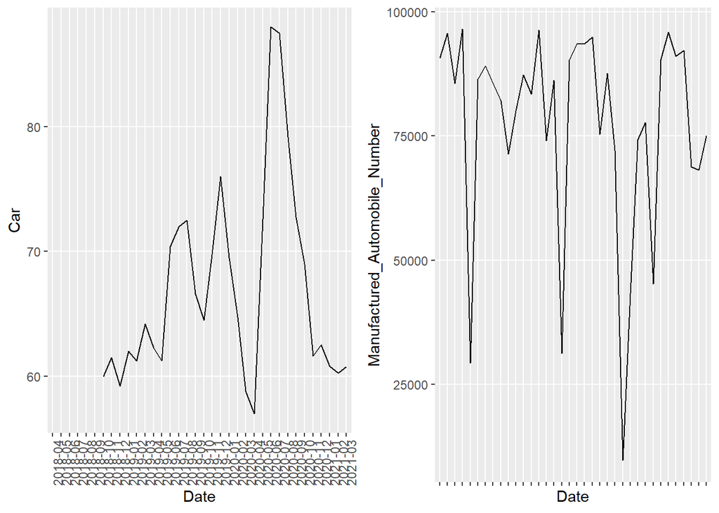

```r
ggarrange(plot_trend3, plot2 + rremove("x.text"),
          ncol = 2, nrow = 1)
```

“araba” key word is used to compare with the manufactured vehicle number. It is expected that the produced car number increase results from the search rate increase for “araba” keyword. However, from the above graphs,it is understood that there is no clear relation between the data and the key word.